# R Notebook

```r
install.packages("agridat")
```

```r
library(tidyverse)
library(agridat)

library(lme4)
library(lmerTest)
library(performance)
library(interactions)
```

In their 1985 paper, Harville and Fenech presented a method for constructing an exact confidence interval for the ratio of two variance components in a linear mixed model. To illustrate their results, the authors used data on the weights at birth of **62 single-birth male lambs**. These lambs come from **five population lines** (two control lines and three selection lines). Each lamb was the offspring of one of **23 rams (male sheep)**, and each lamb had a different mother. The **age of the mother** is one of three categories: *1-2 years (category 1), 2-3 years (category 2), or 3+ years (category 3)*.

```r
data("harville.lamb", package = "agridat")

df_raw <- harville.lamb


df_raw
```

| line | sire | damage | weight |
| --- | --- | --- | --- |
| 1 | 1 | 1 | 6.2 |
| 1 | 2 | 1 | 13.0 |
| 1 | 3 | 1 | 9.5 |
| 1 | 3 | 1 | 10.1 |
| 1 | 3 | 1 | 11.4 |
| 1 | 3 | 2 | 11.8 |
| 1 | 3 | 3 | 12.9 |
| 1 | 3 | 3 | 13.1 |
| 1 | 4 | 1 | 10.4 |
| 1 | 4 | 2 | 8.5 |

[output cut: 52 more lines]

```r
df_long <- df_raw %>%
  dplyr::mutate_at(vars(line, sire),
                   factor) %>%
  dplyr::mutate(damage = factor(damage,
                                levels = 1:3,
                                labels = c("1-2 years",
                                           "2-3 years",
                                           "over 3 years")))

df_long
```

| line | sire | damage | weight |
| --- | --- | --- | --- |
| 1 | 1 | 1-2 years | 6.2 |
| 1 | 2 | 1-2 years | 13.0 |
| 1 | 3 | 1-2 years | 9.5 |
| 1 | 3 | 1-2 years | 10.1 |
| 1 | 3 | 1-2 years | 11.4 |
| 1 | 3 | 2-3 years | 11.8 |
| 1 | 3 | over 3 years | 12.9 |
| 1 | 3 | over 3 years | 13.1 |
| 1 | 4 | 1-2 years | 10.4 |
| 1 | 4 | 2-3 years | 8.5 |

[output cut: 52 more lines]

```
No summary function supplied, defaulting to `mean_se()`
```

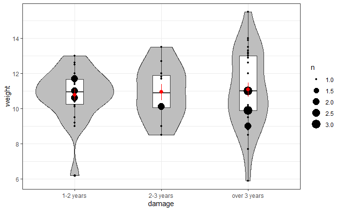

```r
df_long %>%
  ggplot(aes(x = damage,
             y = weight)) +
  geom_violin(fill = "gray") +
  geom_boxplot(width = .2) +
  geom_count() +
  stat_summary(color = "red") +
  theme_bw()
```

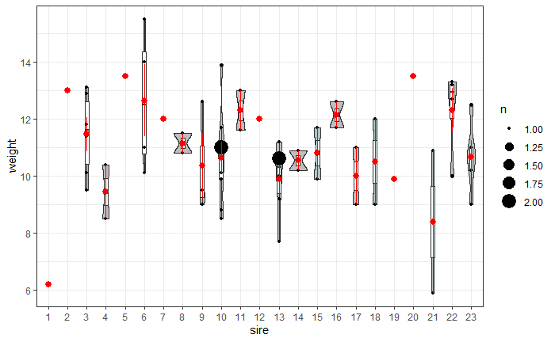

```r
df_long %>%
  ggplot(aes(x = sire,
             y = weight)) +
  geom_violin(fill = "gray") +
  geom_boxplot(width = .2) +
  geom_count() +
  stat_summary(color = "red") +
  theme_bw()
```

```
No summary function supplied, defaulting to `mean_se()`
```

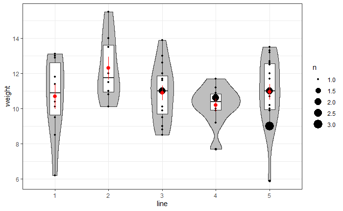

```r
df_long %>%
  ggplot(aes(x = line,
             y = weight)) +
  geom_violin(fill = "gray") +
  geom_boxplot(width = .2) +
  geom_count() +
  stat_summary(color = "red") +
  theme_bw()
```

```r
fit_lmer_0_re <- lmerTest::lmer(weight ~ 1 + (1|sire),
                                data = df_long,
                                REML = TRUE)

fit_lmer_0_ml <- lmerTest::lmer(weight ~ 1 + (1|sire),
                                data = df_long,
                                REML = FALSE)
```

```r
texreg::knitreg(list(fit_lmer_0_re, fit_lmer_0_ml),
                custom.model.names = c("REML", "ML"),
                single.row = TRUE,
                digits = 2,
                caption = "Null Models")
```

[output not shown]

```r
performance::icc(fit_lmer_0_re)
```

```
# Intraclass Correlation Coefficient

     Adjusted ICC: 0.127
  Conditional ICC: 0.127
```

```r
fit_lmer_1_re <- lmerTest::lmer(weight ~line + damage + (1|sire),
                                data = df_long,
                                REML = TRUE)
```

```r
texreg::knitreg(list(fit_lmer_0_re, fit_lmer_1_re),
                single.row = TRUE)
```

[output not shown]

Conditional ICC:

```r
performance::icc(fit_lmer_1_re)
```

```
# Intraclass Correlation Coefficient

     Adjusted ICC: 0.149
  Conditional ICC: 0.135
```

# Carrots Example

In a consumer study 103 consumers scored their preference of 12 danish carrot types on a scale from 1 to 7. Moreover the consumers scored the degree of sweetness, bitterness and crispiness in the products.

- `Consumer` factor with 103 levels: numbering identifying consumers.
- `Frequency` factor with 5 levels; “How often do you eat carrots?”
  - 1: once a week or more,
  - 2: once every two weeks,
  - 3: once every three weeks,
  - 4: at least once month,
  - 5: less than once a month.
- `Gender` factor with 2 levels.
  - 1: male,
  - 2:female.
- `Age` factor with 4 levels.
  - 1: less than 25 years,
  - 2: 26-40 years,
  - 3: 41-60 years,
  - 4 more than 61 years.
- `Homesize` factor with two levels. Number of persons in the household.
  - 1: 1 or 2 persons,
  - 2: 3 or more persons.
- `Work` factor with 7 levels. different types of employment.
  - 1: unskilled worker(no education),
  - 2: skilled worker(with education),
  - 3: office worker,
  - 4: housewife (or man),
  - 5: independent businessman/ self-employment,
  - 6: student,
  - 7: retired
- `Income` factor with 4 levels.
  - 1: <150000,
  - 2: 150000-300000,
  - 3: 300000-500000,
  - 4: >500000
- `Preference` consumer score on a seven-point scale.
- `Sweetness` consumer score on a seven-point scale.
- `Bitterness` consumer score on a seven-point scale.
- `Crispness` consumer score on a seven-point scale.
- `sens1` first sensory variable derived from a PCA.
- `sens2` second sensory variable derived from a PCA.
- `Product` factor on 12 levels.

The carrots were harvested in autumn 1996 and tested in march 1997. In addition to the consumer survey, the carrot products were evaluated by a trained panel of tasters, the sensory panel, with respect to a number of sensory (taste, odour and texture) properties. Since usually a high number of (correlated) properties (variables) are used, in this case 14, it is a common procedure to use a few, often 2, combined variables that contain as much of the information in the sensory variables as possible. This is achieved by extracting the first two principal components in a principal components analysis (PCA) on the product-by-property panel average data matrix. In this data set the variables for the first two principal components are named (sens1 and sens2).

```r
data(carrots, package = "lme4")
```

```r
fit_carrot_lmer_1_re <- lmerTest::lmer(Preference ~ sens2 + Homesize +
                                         (1 + sens2 | Consumer),
                                       data = carrots,
                                       REML = TRUE)

summary(fit_carrot_lmer_1_re)
```

```
Linear mixed model fit by REML. t-tests use Satterthwaite's method ['lmerModLmerTest']
Formula: Preference ~ sens2 + Homesize + (1 + sens2 | Consumer)
   Data: carrots

REML criterion at convergence: 3748.9

Scaled residuals:
    Min      1Q  Median      3Q     Max
-3.5321 -0.5571  0.0309  0.6297  2.8552

Random effects:
 Groups   Name        Variance Std.Dev. Corr
 Consumer (Intercept) 0.195187 0.44180
          sens2       0.002778 0.05271  0.18
 Residual             1.070440 1.03462
Number of obs: 1233, groups:  Consumer, 103

Fixed effects:
              Estimate Std. Error         df t value Pr(>|t|)
(Intercept)   4.910021   0.070563 101.336818  69.584  < 2e-16 ***
sens2         0.070675   0.009545 102.016043   7.404 3.89e-11 ***
Homesize3    -0.249039   0.105378 100.953855  -2.363     0.02 *
---
Signif. codes:  0 ‘***’ 0.001 ‘**’ 0.01 ‘*’ 0.05 ‘.’ 0.1 ‘ ’ 1

Correlation of Fixed Effects:
          (Intr) sens2
sens2      0.061
Homesize3 -0.667  0.000
```

# Ham example

One of the purposes of the study was to investigate the effect of information given to the consumers measured in hedonic liking for the hams. Two of the hams were Spanish and two were Norwegian, each origin representing different salt levels and different aging time. The information about origin was given in such way that both true and false information was given. Essentially a 4x2 design with 4 samples and 2 information levels. A total of 81 Consumers participated in the study.

- `Consumer` factor with 81 levels: numbering identifying consumers.
- `Product` factor with four levels.
- `Informed.liking` numeric: hedonic liking for the products.
- `Information` factor with two levels.
- `Gender` factor with two levels.
- `Age` numeric: age of Consumer.

```r
fit_ham_lmer_0_re <- lmerTest::lmer(Informed.liking ~ 1 + (1|Consumer) ,
                                    data = ham,
                                      REML = TRUE)

fit_ham_lmer_1_re <- lmerTest::lmer(Informed.liking ~ Product*Information + (1|Consumer) ,
                                    data = ham,
                                      REML = TRUE)

fit_ham_lmer_2_refm <- lmerTest::lmer(Informed.liking ~ Product*Information*Gender*Age +
                                        + (1|Consumer) + (1|Consumer:Product) +
                                        (1|Consumer:Information),
                                      data = ham,
                                      REML = TRUE)
```

```r
performance::icc(fit_ham_lmer_0_re)
```

```
# Intraclass Correlation Coefficient

     Adjusted ICC: 0.152
  Conditional ICC: 0.152
```

```r
anova(fit_ham_lmer_1_re)
```

```
Type III Analysis of Variance Table with Satterthwaite's method
                    Sum Sq Mean Sq NumDF DenDF F value    Pr(>F)
Product             91.807 30.6024     3   560  6.9901 0.0001271 ***
Information          6.520  6.5201     1   560  1.4893 0.2228402
Product:Information 10.387  3.4624     3   560  0.7909 0.4992920
---
Signif. codes:  0 ‘***’ 0.001 ‘**’ 0.01 ‘*’ 0.05 ‘.’ 0.1 ‘ ’ 1
```

```r
lmerTest::ranova(fit_ham_lmer_1_re)
```

```
ANOVA-like table for random-effects: Single term deletions

Model:
Informed.liking ~ Product + Information + (1 | Consumer) + Product:Information
               npar  logLik    AIC    LRT Df Pr(>Chisq)
<none>           10 -1435.0 2890.0
(1 | Consumer)    9 -1453.5 2924.9 36.968  1  1.201e-09 ***
---
Signif. codes:  0 ‘***’ 0.001 ‘**’ 0.01 ‘*’ 0.05 ‘.’ 0.1 ‘ ’ 1
```

```r
texreg::knitreg(list(fit_ham_lmer_0_re, fit_ham_lmer_1_re, fit_ham_lmer_2_refm),
                single.row = TRUE)
```

```
===================================================================================================
                                       Model 1              Model 2              Model 3
---------------------------------------------------------------------------------------------------
(Intercept)                                5.73 (0.13) ***      5.73 (0.25) ***      5.75 (1.81) **
Product2                                                       -0.83 (0.33) *       -1.72 (2.45)
Product3                                                        0.15 (0.33)          0.64 (2.45)
Product4                                                        0.30 (0.33)          0.97 (2.45)
Information2                                                    0.16 (0.33)          0.63 (1.43)
Product2:Information2                                           0.25 (0.46)         -0.51 (1.96)
Product3:Information2                                           0.27 (0.46)         -1.68 (1.96)
Product4:Information2                                          -0.36 (0.46)         -2.60 (1.96)
Gender2                                                                              2.14 (2.65)
Age                                                                                  0.00 (0.04)
Product2:Gender2                                                                    -3.83 (3.59)
Product3:Gender2                                                                    -1.93 (3.59)
Product4:Gender2                                                                    -2.63 (3.59)
Information2:Gender2                                                                -0.08 (2.09)
Product2:Age                                                                         0.02 (0.05)
Product3:Age                                                                        -0.01 (0.05)
Product4:Age                                                                        -0.02 (0.05)
Information2:Age                                                                    -0.01 (0.03)
Gender2:Age                                                                         -0.05 (0.06)
Product2:Information2:Gender2                                                        3.77 (2.86)
Product3:Information2:Gender2                                                       -0.05 (2.86)
Product4:Information2:Gender2                                                        3.27 (2.86)
Product2:Information2:Age                                                            0.02 (0.04)
Product3:Information2:Age                                                            0.05 (0.04)
Product4:Information2:Age                                                            0.06 (0.04)
Product2:Gender2:Age                                                                 0.08 (0.08)
Product3:Gender2:Age                                                                 0.04 (0.08)
Product4:Gender2:Age                                                                 0.07 (0.08)
Information2:Gender2:Age                                                             0.01 (0.04)
Product2:Information2:Gender2:Age                                                   -0.10 (0.06)
Product3:Information2:Gender2:Age                                                   -0.01 (0.06)
Product4:Information2:Gender2:Age                                                   -0.09 (0.06)
---------------------------------------------------------------------------------------------------
AIC                                     2895.05              2889.97              2833.00
BIC                                     2908.47              2934.71              2994.06
Log Likelihood                         -1444.53             -1434.99             -1380.50
Num. obs.                                648                  648                  648
Num. groups: Consumer                     81                   81                   81
Var: Consumer (Intercept)                  0.81                 0.83                 0.32
Var: Residual                              4.52                 4.38                 1.55
Num. groups: Consumer:Product                                                      324
Num. groups: Consumer:Information                                                  162
Var: Consumer:Product (Intercept)                                                    3.32
Var: Consumer:Information (Intercept)                                                0.10
===================================================================================================
*** p < 0.001; ** p < 0.01; * p < 0.05
```

[figure not shown]

```r
fit_ham_lmer_1_re %>%
  emmeans::emmeans(pairwise ~ Product)
```

```
NOTE: Results may be misleading due to involvement in interactions
```

```
$emmeans
 Product emmean    SE  df lower.CL upper.CL
 1         5.81 0.193 320     5.43     6.19
 2         5.10 0.193 320     4.73     5.48
 3         6.09 0.193 320     5.71     6.47
 4         5.93 0.193 320     5.55     6.31

Results are averaged over the levels of: Information
Degrees-of-freedom method: kenward-roger
Confidence level used: 0.95

$contrasts
 contrast estimate    SE  df t.ratio p.value
 1 - 2       0.704 0.232 560   3.027  0.0137
 1 - 3      -0.284 0.232 560  -1.221  0.6135
 1 - 4      -0.117 0.232 560  -0.504  0.9580
 2 - 3      -0.988 0.232 560  -4.248  0.0001
 2 - 4      -0.821 0.232 560  -3.531  0.0025
 3 - 4       0.167 0.232 560   0.717  0.8904

Results are averaged over the levels of: Information
Degrees-of-freedom method: kenward-roger
P value adjustment: tukey method for comparing a family of 4 estimates
```

```r
totalSD <- VarCorr(fit_ham_lmer_1_re) %>%
  data.frame() %>%
  dplyr::summarise(tot_var = sum(vcov)) %>%
  dplyr::pull(tot_var) %>%
  sqrt()

totalSD
```

```
[1] 2.28107
```

These effect sizes can be interpreted according to Cohen’s rule: * 0.2 represents a small effect size, * 0.5 represents a medium effect size and * 0.8 represents a large effect size.

```r
fit_ham_lmer_1_re %>%
  emmeans::emmeans(~ Product) %>%
  emmeans::eff_size(sigma = totalSD,  # population SD
                    edf = Inf)         # equivalent degrees of freedom for the sigma
```

```
NOTE: Results may be misleading due to involvement in interactions
```

```
 contrast effect.size    SE  df lower.CL upper.CL
 1 - 2         0.3085 0.102 320    0.108    0.509
 1 - 3        -0.1245 0.102 320   -0.325    0.076
 1 - 4        -0.0514 0.102 320   -0.252    0.149
 2 - 3        -0.4330 0.102 320   -0.633   -0.232
 2 - 4        -0.3599 0.102 320   -0.560   -0.159
 3 - 4         0.0731 0.102 320   -0.127    0.274

Results are averaged over the levels of: Information
sigma used for effect sizes: 2.281
Degrees-of-freedom method: inherited from kenward-roger when re-gridding
Confidence level used: 0.95
```

https://www.r-bloggers.com/2021/02/split-plot-designs-the-transition-to-mixed-models-for-a-dinosaur/

https://bcdudek.net/repeat1/linear-mixed-models.html

```r
fit_ham_lmer_1_re %>%
  lmerTest::difflsmeans(which = "Product")
```

```
Least Squares Means table:

                    Estimate Std. Error  df t value    lower    upper  Pr(>|t|)
Product1 - Product2  0.70370    0.23248 560  3.0269  0.24706  1.16035 0.0025845 **
Product1 - Product3 -0.28395    0.23248 560 -1.2214 -0.74060  0.17270 0.2224578
Product1 - Product4 -0.11728    0.23248 560 -0.5045 -0.57393  0.33936 0.6141217
Product2 - Product3 -0.98765    0.23248 560 -4.2483 -1.44430 -0.53101 2.523e-05 ***
Product2 - Product4 -0.82099    0.23248 560 -3.5314 -1.27764 -0.36434 0.0004475 ***
Product3 - Product4  0.16667    0.23248 560  0.7169 -0.28998  0.62331 0.4737382
---
Signif. codes:  0 ‘***’ 0.001 ‘**’ 0.01 ‘*’ 0.05 ‘.’ 0.1 ‘ ’ 1

  Confidence level: 95%
  Degrees of freedom method: Satterthwaite
```

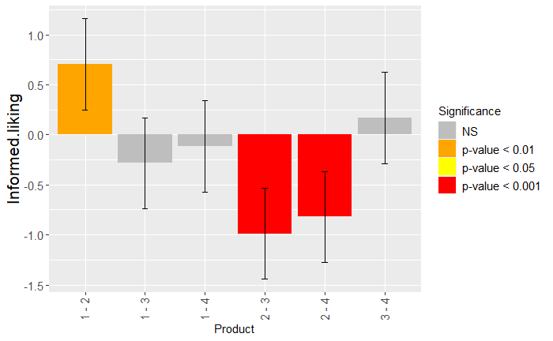